# Introduction

- Learning outcomes:
  - Understand idea/aims/advantages/steps of interactive data analysis
  - Understand basic structure of Shiny apps (components)
  - Quick overview of our ESS app
  - Discuss MVP and workflow

Sources: Bertini (2017), Wickham (2021) and Fay et al. (2021)

## 1 Interactive data analysis

- Source(s): Bertini (2017) and others.

### 1.1 Why?

- “From Data Visualization to Interactive Data Analysis” (Bertini 2017)
- Main uses of data visualization: Inspirational, explanatory and analytical[^1]
- “data analysis […] can help people improve their understanding of complex phenomena”
  - *“if I understand a problem better, there are higher chances I can find a better solution for it”*

### 1.2 Interactivity data visualization history

- “**interactive data visualization** enables direct actions on a plot to change elements and link between multiple plots” (Swayne 1999) ([Wikipedia](https://en.wikipedia.org/wiki/Interactive_data_visualization))
- Interactivity revolutionizes the way we work with and how we perceive data (cf. Cleveland and McGill 1984)
- Started ~last quarter of the 20th century, PRIM-9 (1974) (Friendly 2006, 23, see also Cleveland and McGill, 1988, Young et al. 2006)
  - We have come a long way… [John Tukey on prim9](https://youtu.be/B7XoW2qiFUA?t=151)
- Interactivity allows for…
  - …making sense of big data (more dimensions)
  - …exploring data
  - …making data accessible to those without background
  - …generating interactive “publications”

### 1.3 How Does Interactive Data Analysis Work?

- Figure 1 outlines process underlying interactive data analysis
  - **Loop**
    - start with loosely specified goal/problem (*Decrease crime!*)
    - translate goal into one or more questions (*What causes crime?*)
    - gather, organize and analyze the data to answer these questions (*Gather **data** on crime and other factors, **model** and **visualize** it*)
    - generate knowledge and new questions and start over

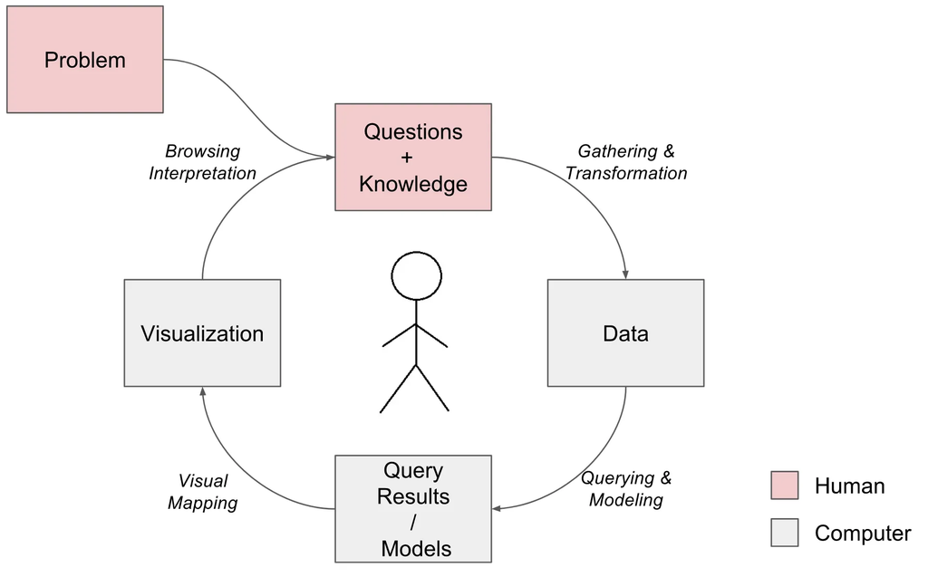

Figure 1: Process underlying interactive data analysis (Source: Bertini, 2017)

### 1.4 Steps of interactive data analysis

1. **Defining the problem**: What problem/goal are you trying to solve/reach through interactive data analysis?
2. **Generating questions**: Translate high-level problem into number of data analysis questions
3. **Gathering, transforming and familiarizing with the data**, e.g., often slicing, dicing and aggregating the data and to prepare it for the analysis one is planning to perform.
4. **Creating models out of data** (not always): using statistical modeling and machine learning methods to summarize and analyze data
5. **Visualizing data and models**: results obtained from data transformation and querying (or from some model) are turned into something our **eyes can digest** and hopefully understand.
   - **Simple representations** like tables and lists rather than fancy charts are perfectly reasonable visualization for many problems.
6. **Interpreting the results**: once results have been generated and represented in visual format, they need to be interpreted by someone (crucial step!)
   - **complex activity** including understanding how to **read the graph**, understanding what graph communicates about phenomenon of interest, **linking results to questions** and pre-existing knowledge of problem (think of your **audience**!)
   - **Interpretation** heavily **influenced** by **pre-existing knowledge** (about domain problem, data transformation process, modeling, visual representation)
7. **Generating inferences and more questions**: steps above lead to creating new knowledge, additional questions or hypotheses
   - **Outcome**: not only answers but also (hopefully better, more refined) questions

### 1.5 Important aspects of data analysis & quo vadis interaction?

- **Process** not sequential but **highly iterative** (jumping back/forth between steps)
- **Some activities exclusively human**, e.g., defining problems, generating questions, etc.
- **Visualization only small portion** of process and effectiveness depends on other steps
- **Interaction**: all over the place… every time you tell your computer what to do (and it returns information)
  - Gather and transform the data
  - Specify a model and/or a query from the data
  - Specify how to represent the results (and the model)
  - Browse the results
  - Synthesize and communicate the facts gathered
- **Direct manipulation vs. command-Line interaction**: WIMP interfaces (direct manipulation, clicks, mouse overs, etc.,) are interactive but so is command line
  - You can let users type!
- **Audience**: what (interaction) skills and pre-knowledge do the have? (domain knowledge, statistics, graphs)

### 1.6 Challenges of Interactive Visual Data Analysis

- Broadly three parts… (Bertini 2017)
- **Specification (Mind → Data/Model)**: necessary to translate our questions and ideas into specifications the computer can read
  - Shiny allows non-coders to perform data analysis, but requires R knowledge to built apps
  - But even simpler tools out there
- **Representation (Data/Model → Eyes)**
  - next step is to find a (visual) representation so users can inspect and understand them
  - “deciding **what to visualize** is often equally, if not more, important, than deciding **how to visualize** it”
  - “how fancy does a visualization need to be in order to be useful for data analysis?”
    - “most visualization problems can be solved with a handful of graphs”
  - really hard to use, tweak, and combine graphs in clever/effective/innovative ways
- **Interpretation (Eyes → Mind)**
  - “what does one need to know in order to reason effectively about the results of modeling and visualization?”
  - “Are people able to interpret and trust [your shiny app]?”

## 2 Why visualize?

### 2.1 Anscombes’s quartet (1)

- Table 1 shows results from a linear regression based on Anscombe’s quartet (Anscombe 1973) often used to illustrate the usefulness of visualization
  - Q: What do we find here?

Table 1: Linear models based on sets of Anscombe’s quartet

|  | y1 (Set 1) | y2 (Set 2) | y3 (Set 3) | y4 (Set 4) |
| --- | --- | --- | --- | --- |
| (Intercept) | 3.000 | 3.001 | 3.002 | 3.002 |
|  | (1.125) | (1.125) | (1.124) | (1.124) |
| x1 | 0.500 |  |  |  |
|  | (0.118) |  |  |  |
| x2 |  | 0.500 |  |  |
|  |  | (0.118) |  |  |
| x3 |  |  | 0.500 |  |
|  |  |  | (0.118) |  |
| x4 |  |  |  | 0.500 |
|  |  |  |  | (0.118) |

### 2.2 Anscombes’s quartet (2)

- Table 2 displays Anscombe’s quartet (Anscombe 1973), a dataset (or 4 little datasets)
  - Q: What does the table reveal about the data? Is it easy to read?

Table 2: Anscombe’s quartett: Visualization

Anscombe's quartet data

| x1 | y1 | x2 | y2 | x3 | y3 | x4 | y4 |
| --- | --- | --- | --- | --- | --- | --- | --- |
| 10 | 8.04 | 10 | 9.14 | 10 | 7.46 | 8 | 6.58 |
| 8 | 6.95 | 8 | 8.14 | 8 | 6.77 | 8 | 5.76 |
| 13 | 7.58 | 13 | 8.74 | 13 | 12.74 | 8 | 7.71 |
| 9 | 8.81 | 9 | 8.77 | 9 | 7.11 | 8 | 8.84 |
| 11 | 8.33 | 11 | 9.26 | 11 | 7.81 | 8 | 8.47 |
| 14 | 9.96 | 14 | 8.10 | 14 | 8.84 | 8 | 7.04 |
| 6 | 7.24 | 6 | 6.13 | 6 | 6.08 | 8 | 5.25 |
| 4 | 4.26 | 4 | 3.10 | 4 | 5.39 | 19 | 12.50 |
| 12 | 10.84 | 12 | 9.13 | 12 | 8.15 | 8 | 5.56 |
| 7 | 4.82 | 7 | 7.26 | 7 | 6.42 | 8 | 7.91 |
| 5 | 5.68 | 5 | 4.74 | 5 | 5.73 | 8 | 6.89 |

### 2.3 Anscombes’s quartet (3)

- Figure 2 finally visualizes the data underlying those data
  - Q: *What do we see here? What is the insight?*

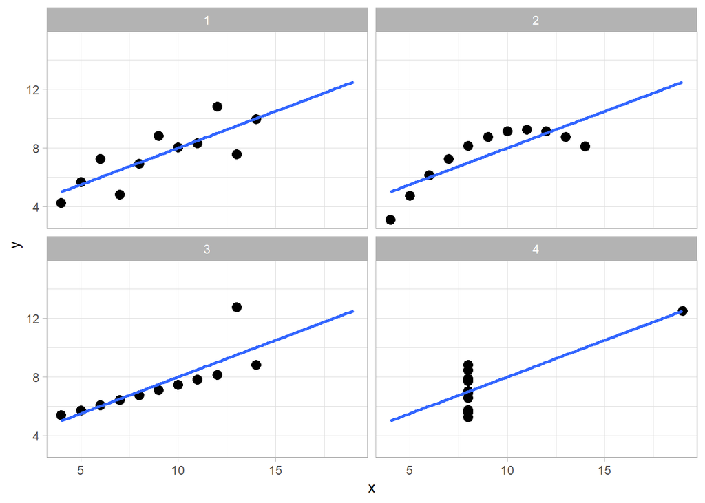

Figure 2: Anscombe’s quartet: Visualization

### 2.4 The Datasaurus Dozen

- Figure 3 displays the datasaurus dozen as animated by [Tom Westlake](https://github.com/thomasp85/gganimate/wiki/The-Datasaurus-Dozen) (see [here](https://github.com/thomasp85/gganimate/wiki/The-Datasaurus-Dozen), original by [Alberto Cairo](http://www.thefunctionalart.com/2016/08/download-datasaurus-never-trust-summary.html))
  - Q: *What do we see here? What is the insight?*

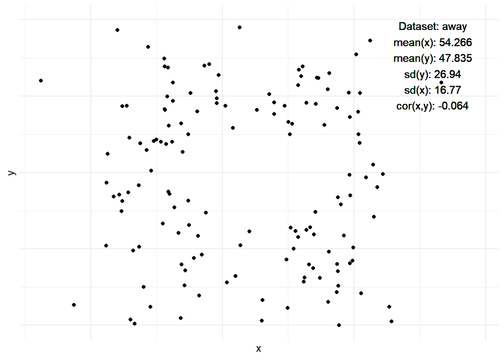

Figure 3: The Datasaurus Dozen animated by Tom Westlake

## 3 Shiny

### 3.1 What is Shiny?

- History of Shiny: [Joe Cheng: The Past and Future of Shiny](https://www.youtube.com/watch?v=HpqLXB_TnpI)[^2]
- **Popularity**: Shiny

[figure not shown]

  (vs. Ggplot2

[figure not shown]

  , dplyr

[figure not shown]

  )
- A **web application framework** for R to turn analyses into interactive web applications.. what does that mean?
  - The userinterface is a **webpage**
  - On this webpage you can manipulate things
  - Behind the webpage there is a computer (your computer or a **server**)
  - That computer/server runs R and the R script of the webapp
  - When you change something on the webpage, the information is send to the computer
  - Computer runs the script with the new **inputs** (**input functions**)
  - Computer sends back **outputs** to the webpage (**output functions**)

[figure not shown]

### 3.2 Components of a Shiny app

- As depicted in Figure 4, a user interacts with a server on which the shinyapp/website is hosted
  - A Shiny app has **two components**, the **user interface (UI)** and the **server**, that are passed as arguments to the `shinyApp()` which creates a Shiny app from this **ui/server pair**

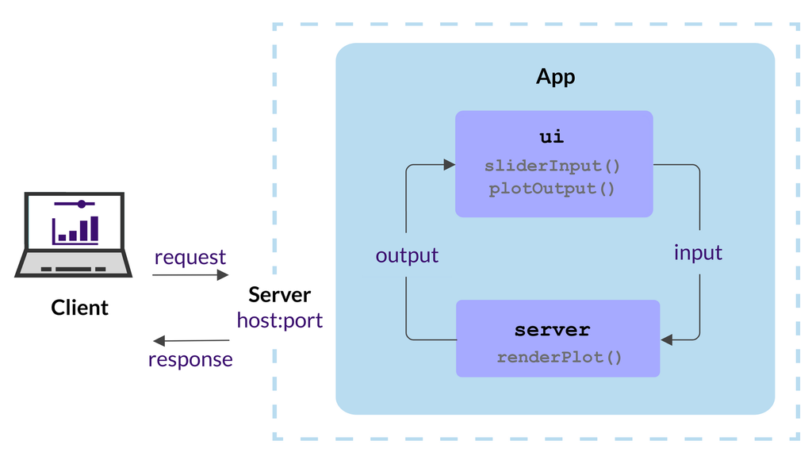

Figure 4: Source: https://hosting.analythium.io/the-anatomy-of-a-shiny-application/ (c) Analythium

### 3.3 Pro & contra Shiny

#### 3.3.1 Pros of R Shiny:

1. **Fast Prototyping**: Shiny is excellent for quickly turning ideas into applications; easy to use even for non-seasoned programmers
2. **Interactivity**: lets you build interactive web apps, enhancing user engagement and experience (dashboards!)
3. **Integration with R Ecosystem**: integrates seamlessly with R’s **vast open-source ecosystem** (see [shiny for python](https://shiny.posit.co/py/))
4. **Statistical Modeling and Visualization**: allows for complex statistical modeling and visualizations within your app
5. **No Need for Web Development Skills**: Create web apps with R code alone (no need for HTML, CSS, or JavaScript)
6. **Reactivity**: fairly simple to create applications that automatically update in response to user inputs
7. **Sharing and Publishing**: apps can be easily published and shared (e.g., Shinyapps.io or shinylive)

#### 3.3.2 Cons of R Shiny:

1. **Performance**: apps run on top of R, an interpreted language, which can cause performance issues
2. **Single-threaded**: R (and by extension Shiny) is single-threaded, which can also cause performance issues (see [here](https://shiny.posit.co/r/articles/improve/scaling-and-tuning/)).
3. **Complexity**: Shiny’s basics are easy but mastering intricacies of reactivity is more challenging
4. **Data Gathering and Saving**: It can be challenging to use Shiny for gathering and saving data to the database.
5. **Maintenance Cost**: cost of maintaining a Shiny application over time can be high (now we have shinylive!)
6. **Software Dependencies**: Certain Shiny applications may have many software dependencies, which could potentially lead to issues down the line

## 4 Exploring European Social Survey (ESS): The app we will build

- In the workshop we will built the Shiny app shown in Figure 5 together. Please [explore this app here](https://paulbauer.shinyapps.io/ess_shinyapp/) (5-10 minutes) and answer the following questions:
  - What questions can we answer using the app?
  - How can this app help us to understand and analyze the underlying data?
  - What interactive elements can we identify in the app?

[figure not shown]

Figure 5: (Source: Original image)

### 4.1 The data

- In our app we will analyze datasets from the [European Social Survey](https://www.europeansocialsurvey.org/), Round 10

**Data preparation code of the app**

```r
data <- readRDS("./data/ess_trust.rds")

kable(head(data))
```

Table 3: Data from the European Social Survey, Round 10

| idno | country | internet_use | trust_parliament | trust_legal | trust_police | trust_politicians | trust_parties | trust_eu | trust_un | left_right | happiness | age | income_feeling |
| --- | --- | --- | --- | --- | --- | --- | --- | --- | --- | --- | --- | --- | --- |
| 27 | AT | 5 | 5 | 10 | 10 | 5 | 5 | 5 | 5 | 9 | 7 | 43 | 3 |
| 137 | AT | 5 | 7 | 8 | 8 | 3 | 4 | 5 | 2 | 5 | 8 | 67 | 2 |
| 194 | AT | 4 | 6 | 8 | 8 | 5 | 5 | 5 | 5 | 5 | 9 | 40 | 1 |
| 208 | AT | 5 | 0 | 5 | 8 | 3 | 3 | 0 | 2 | NA | 8 | 63 | 2 |
| 220 | AT | 1 | 7 | 8 | 8 | 7 | 7 | 5 | 5 | 5 | 8 | 71 | 2 |
| 254 | AT | 2 | 6 | 5 | 7 | 5 | 5 | 4 | 6 | 3 | 9 | 64 | 1 |

- `data` (see Table 3) comprises 49519 individuals that live in 29 countries (File: `ess_trust.rds`)
  - Later on we also aggregate the data to the country-level

**Data preparation code of the app**

```r
data_geo <- readRDS("./data/ess_trust_geo.rds")
# View(data_geo)
```

## 5 Your (first) Shiny app

- Below you will create you first app and we’ll use the opportunity to discuss the basic components of a shiny app (see analogous example [here](https://mastering-shiny.org/basic-app.html#basic-app)).
1. Install the relevant packages:

```r
install.packages("shiny")
install.packages("tidyverse")
```

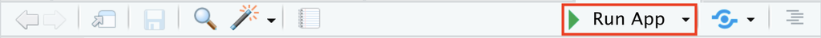

Figure 6: The Run App button can be found at the top-right of the source pane.

## 6 Minimum viable product (MVP)

- …useful concept when building apps (see Figure 7)!

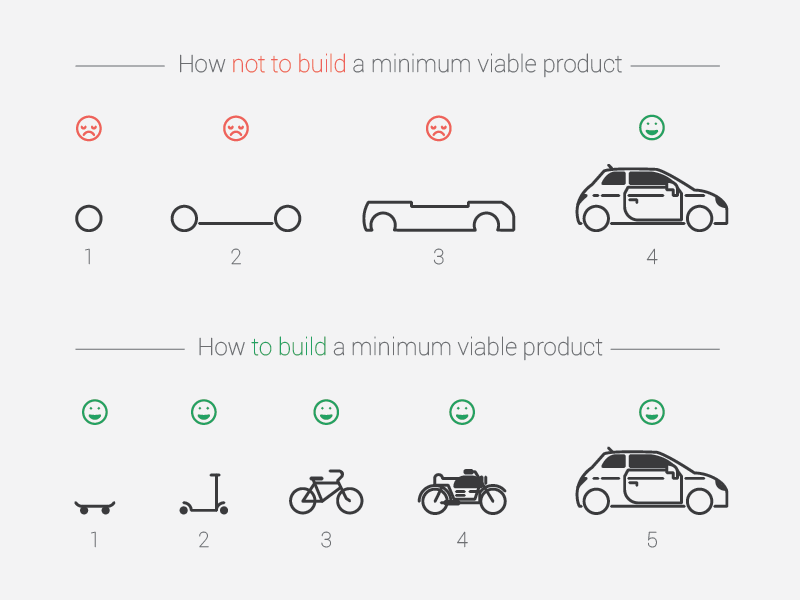

Figure 7: Illustration of MVP (Source: Fay et al. 2021 - [read description](https://engineering-shiny.org/building-ispum-app.html))

- “**version** […] with **just enough features to be usable** by early customers” to collect feedback ([Wikipedia](https://en.wikipedia.org/wiki/Minimum_viable_product))
- “Making things work before working on low-level optimization makes the whole engineering process easier” (Fay et al. 2021)
- **The “UI first” approach**: often the safest way to go (Fay et al. 2021)
  - **Agreeing on specifications**: helps everybody involved in the application to agree on what the app is supposed to do, and once the UI is set, there should be no “surprise implementation”
  - **Organizing work**: “It’s much easier to work on a piece of the app you can visually identify and integrate in a complete app scenario”
  - But…
- ..we “follow” same strategy, slowly building out our shiny app, adding features & complexity

## 7 Workflow: Development, debugging and getting help

- See discussions of workflow in Wickham (2021, Ch. 5, 20.2.1)
- Three important Shiny workflows:
  - **Basic development** cycle of creating apps, making changes, and experimenting with the results.
  - **Debugging**, i.e., figure out what’s gone wrong with your code/brainstorm solutions
  - **Writing reprexes**, self-contained chunks of code that illustrate a problem (essential for getting others’ help)
- Below development WF, debugging later on

### 7.1 Development workflow

1. **Creating the app**: start every app with the same lines of R code below (`Shift + Tab` or in menue `New Project -> Shiny Web Application`)
2. **Seeing your changes**: you’ll create a few apps a day (really?!?), but you’ll run apps hundreds of times, so mastering the development workflow is particularly important
3. Write some code.[^3]
4. Launch the app with `Cmd/Ctrl + Shift + Enter`.
5. Interactively experiment with the app.
6. Close the app.
7. Go back to 1.

```r
library(shiny)
ui <- fluidPage(

)
server <- function(input, output, session) {

}
shinyApp(ui, server)
```

#### 7.1.1 Rstudio & Shiny: A few tips

- **Controlling the view**: Default is a pop-out window but you can also choose `Run in Viewer Pane` and `Run External`.
- **Document outline**: Use it for navigation in your app code (`Cntrl + Shift + O`)
- **Using/exploring other apps**: Inspect that app code, then slowly delete parts you don’t need
  - Rerun app to see whether it still works after each deletion
  - if only interested in UI, delete everything in within server function: `server <- function(input, output, session) {delete everything here}`
  - **Important**: Search for dependencies (that can sometimes be delete), e.g., search for `www` folder
    - also image links with `src` or `png`, `jpg`

### 7.2 Debugging workflow

- Guaranteed that something will go wrong at the start
- Cause is **mismatch** between your **mental model of Shiny**, and **what Shiny actually does**
- We need to develop **robust workflow for identifying and fixing mistakes**
- Three main cases of problems: **(1) Unexpected error**, **(2) No error but incorrect values**; **(3) Correct values but not updated**
  - 1. Use traceback and interactive debugger
  - 2. Use interactive debugger
  - 3. Problem unique to Shiny, i.e., R skills don’t help
- See Wickham (2021, Ch. 5.2, [link](https://mastering-shiny.org/action-workflow.html#debugging)) for explanations and examples

## References

Anscombe, F J. 1973. “Graphs in Statistical Analysis.” *Am. Stat.* 27 (1): 17–21.

Bertini, Enrico. 2017. “From Data Visualization to Interactive Data Analysis.” https://medium.com/@FILWD/from-data-visualization-to-interactive-data-analysis-e24ae3751bf3.

Cleveland, William S, and Robert McGill. 1984. “Graphical Perception: Theory, Experimentation, and Application to the Development of Graphical Methods.” *Journal of the American Statistical Association* 79 (387): 531–54.

Fay, Colin, Sébastien Rochette, Vincent Guyader, and Cervan Girard. 2021. *Engineering Production-Grade Shiny Apps*. CRC Press.

Friendly, Michael. 2006. “A Brief History of Data Visualization.” In *Handbook of Data Visualization*, 15–56. Springer Handbooks Comp.statistics. Springer Berlin Heidelberg.

Swayne, Deborah. 1999. “Introduction to the Special Issue on Interactive Graphical Data Analysis: What Is Interaction?” *Computational Statistics* 14 (1): 1–6.

Wickham, Hadley. 2021. *Mastering Shiny*. " O’Reilly Media, Inc.".

## Footnotes

[^1]: **Inspirational**. The main goal here is to inspire people. To wow them! But not just on a superficial level, but to really engage people into deeper thinking, sense of beauty and awe. **Explanatory**. The main goal here is to use graphics as a way to explain some complex idea, phenomenon or process. **Analytical**. The main goal here is to extract information out of data with the purpose of answering questions and advancing understanding of some phenomenon of interest.
[^2]: Joe Cheng is the Chief Technology Officer at RStudio and was the original creator of the Shiny web framework, and continues to work on packages at the intersection of R and the web.
[^3]: **Automated testing**: allows you to turn interactive experiments you’re running into automated code, i.e., run tests more quickly and not forget them (because they are automated). Requires more initial investment.